# Comparing MT State LiDAR and 2023 Veg Surveys

Anna Kurtin

2024-01-24

# Looking at Initial Agreement Between Methods

First, I plotted the measurements from each method against each other to evaluate how close they were to 1:1. Then, I generated graphs that colored the points according to:

- the year the data was collected
- the season it was collected (summer being between June and September, not_summer being outside of that period)
- the protocol used to collect the data (USGS 3DEP is the new standard, non 3DEP was collected earlier and initial measurements were in ft not meters)

### Agreement Between Methods: Canopy Height

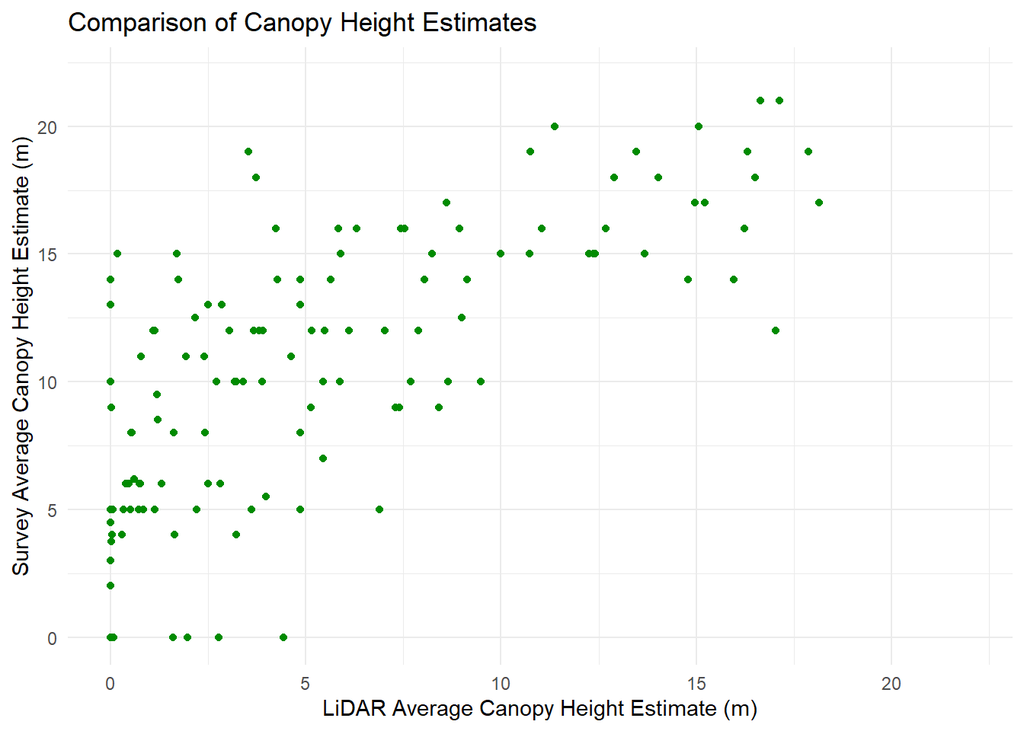

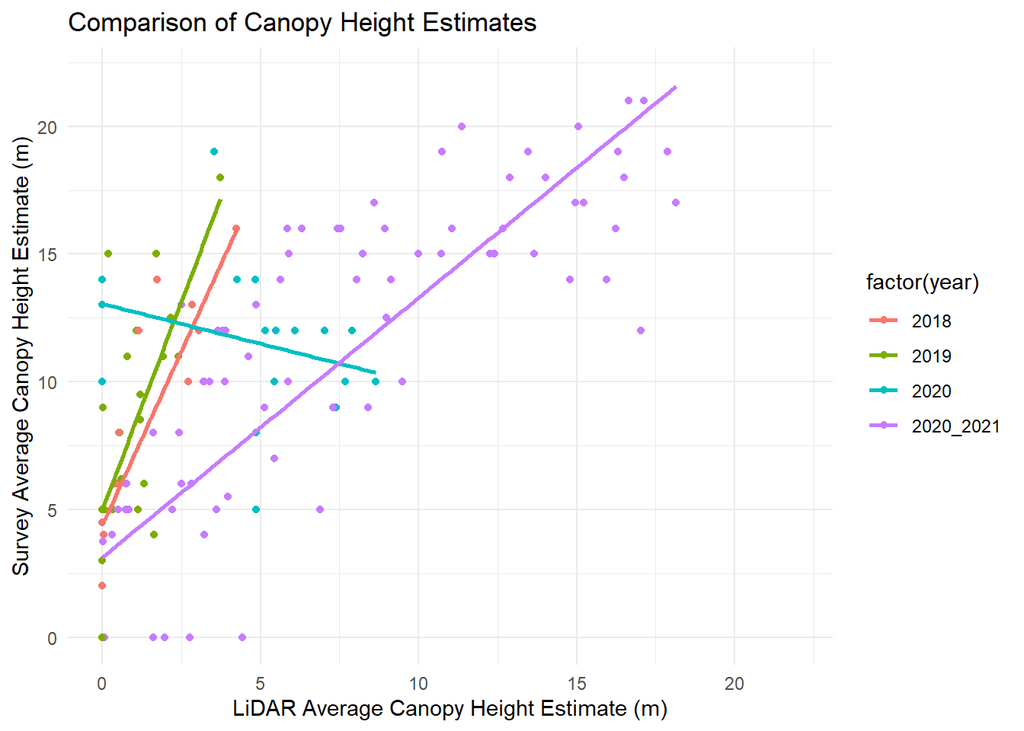

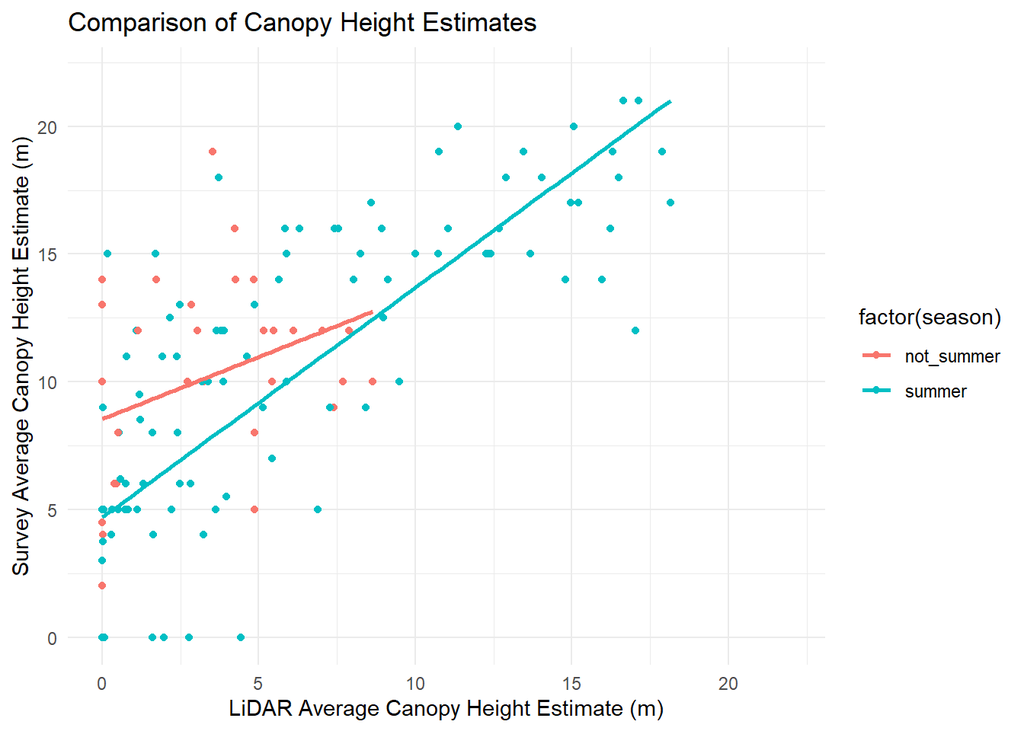

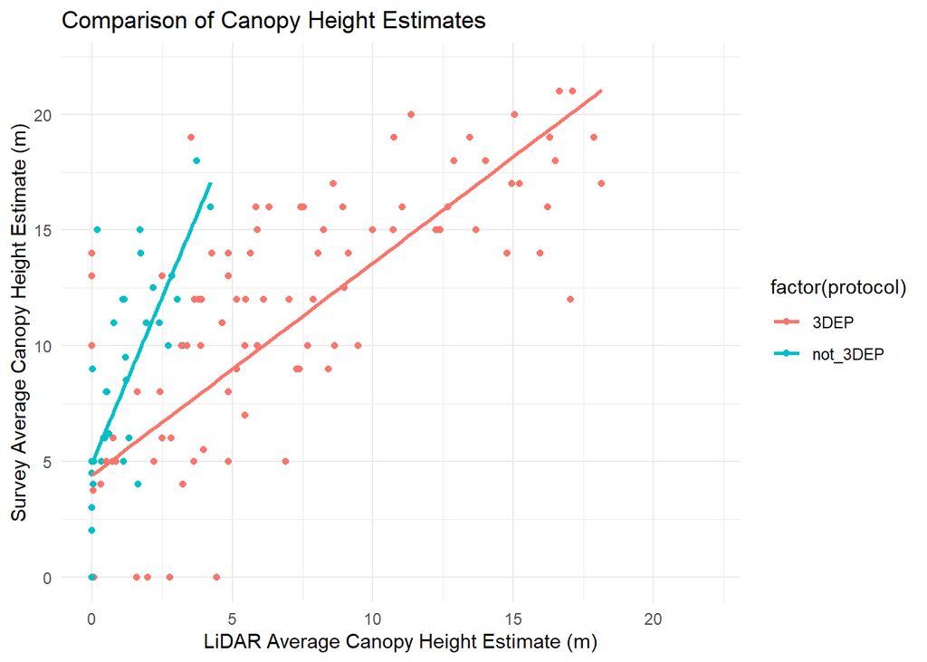

### Agreement Between Methods: Canopy Cover

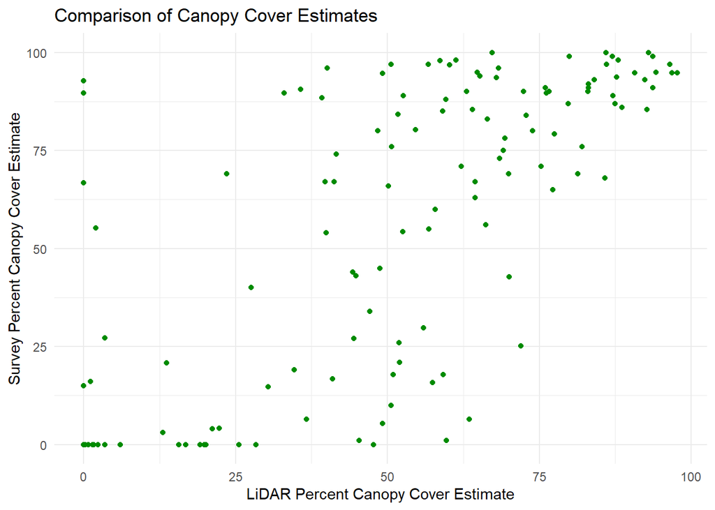

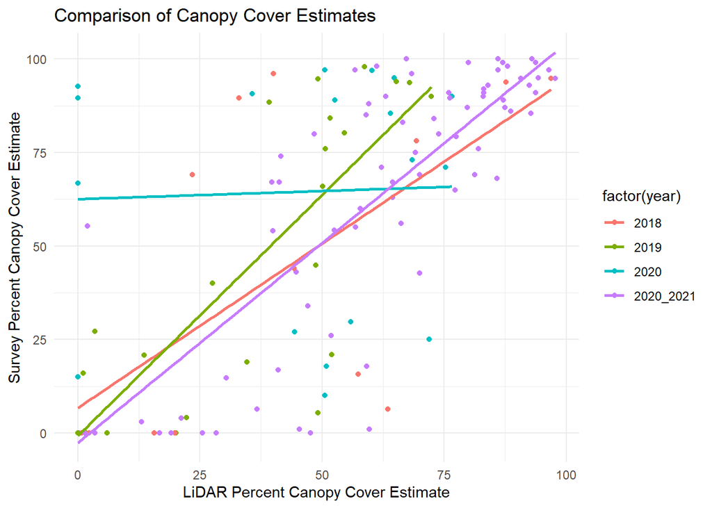

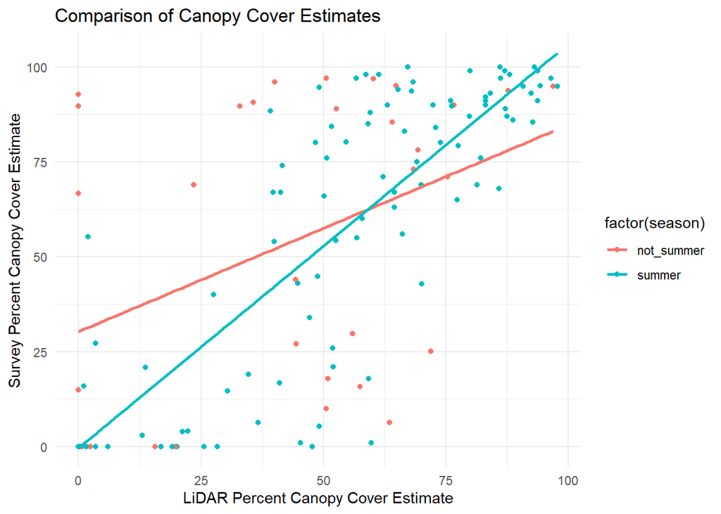

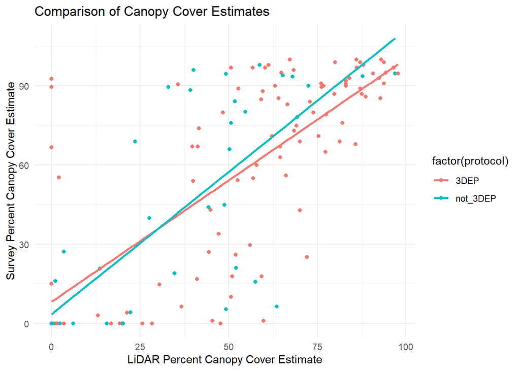

The cleanest data looks to be data from summer collected via 3DEP from 2020-2021.

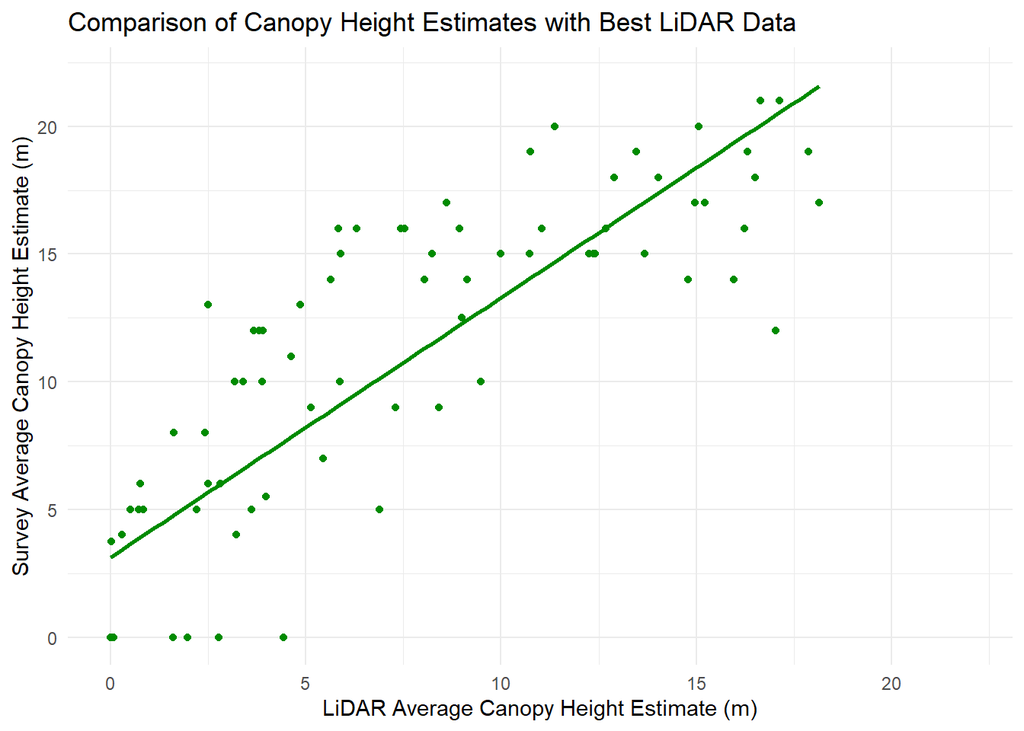

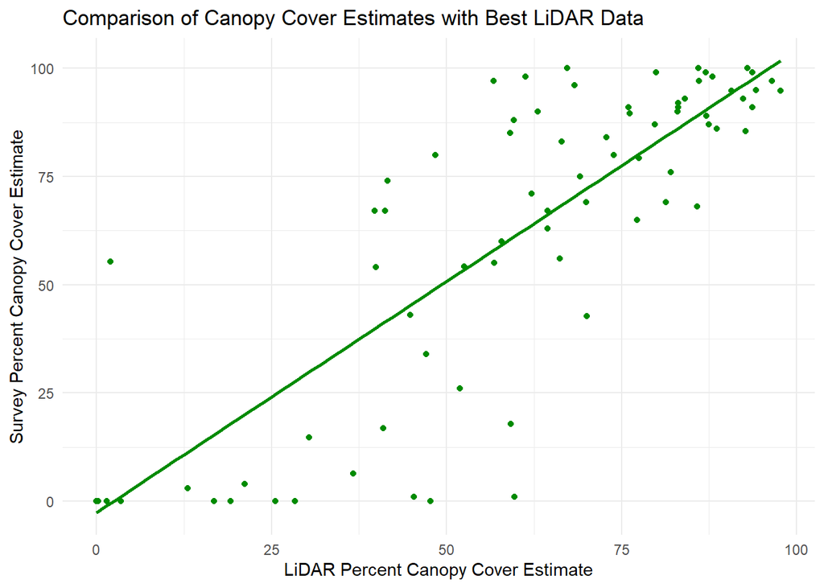

So just looking at the cleanest LiDAR data, we see pretty expected patterns. The height is generally estimated higher from surveys, whether from veg growing in or human bias is hard to say. Canopy cover is more variable in general, and at percentages estimated less than 30% from the LiDAR data, the survey estimates were much lower, likely due to the use of the densiometer.

The messiest data looks to be data from not summer collected not via 3DEP from 2020. There is no data for this, however, because 2020 was exclusively collected via 3DEP, but wasn’t collected during the summer. To me it looks like the reason why the 2020 data looks bad is because it was collected only outside of summer, even if it was the 3DEP protocol.

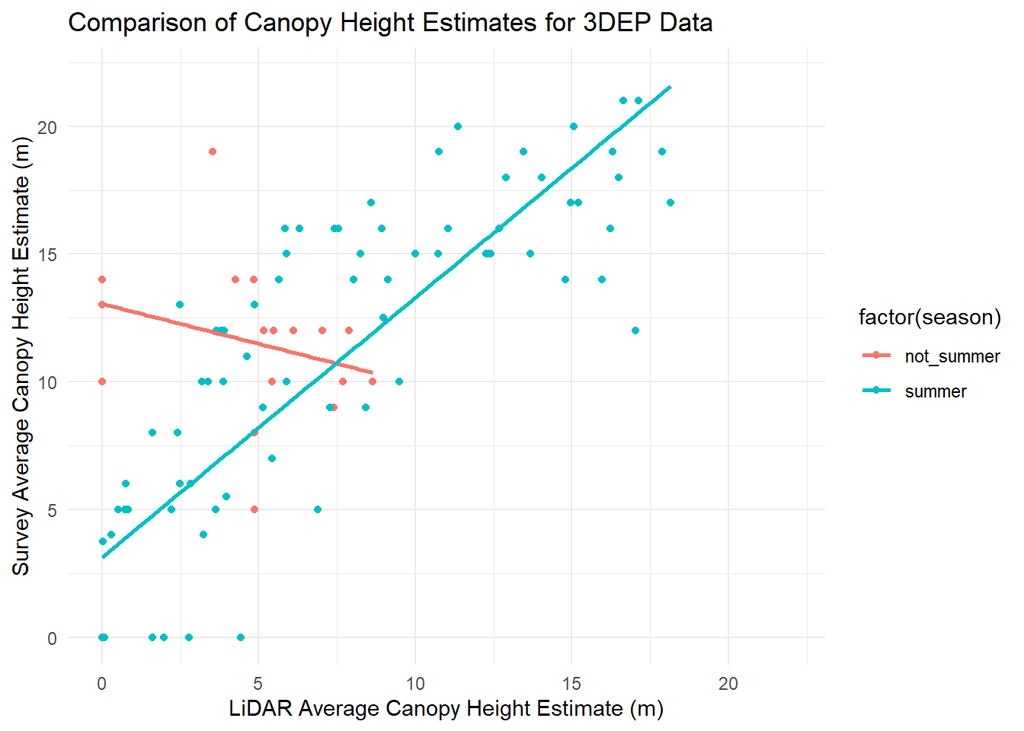

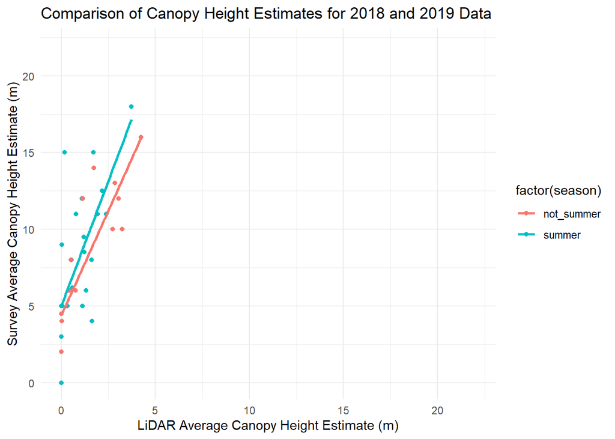

Just the in summer vs out of summer didn’t change the results as much as we expected. It looks like this messiness is mainly driven by the 2020 data.

## Compare density metrics

I normalized the measurements for canopy height and canopy cover and added them for each method to get a metric for “density”. Points with a higher density score have tall canopies and high canopy cover, while points with a lower density score have a short canopy and low canopy cover. In the following graphs, I’ve plotted the measurements for each method with the density score for each plot corresponding to color. Notice how the color follows a smooth gradient across the graph.

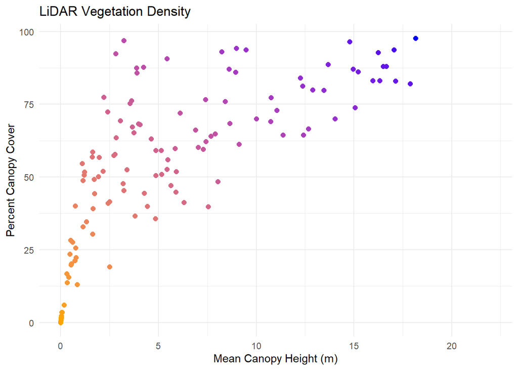

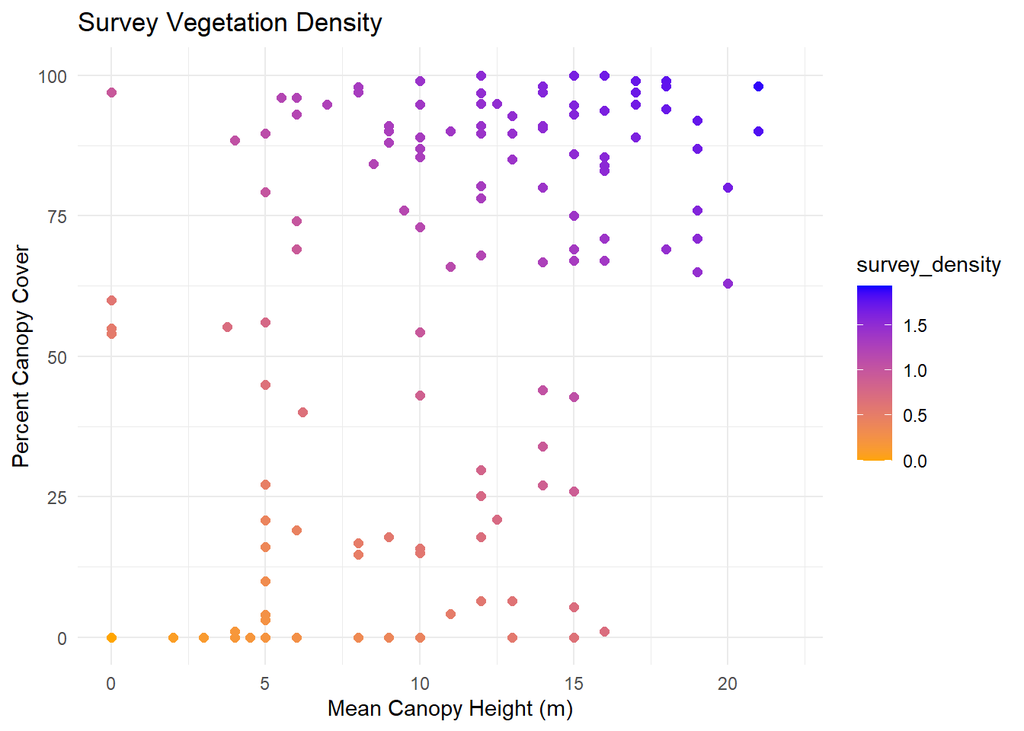

Now, we’re going to switch the coloration. The axes are still the same, but now the color shows the density metric for the other method. If these methods were clustering the density of plots the same, these should still follow a smooth gradient along the graph.

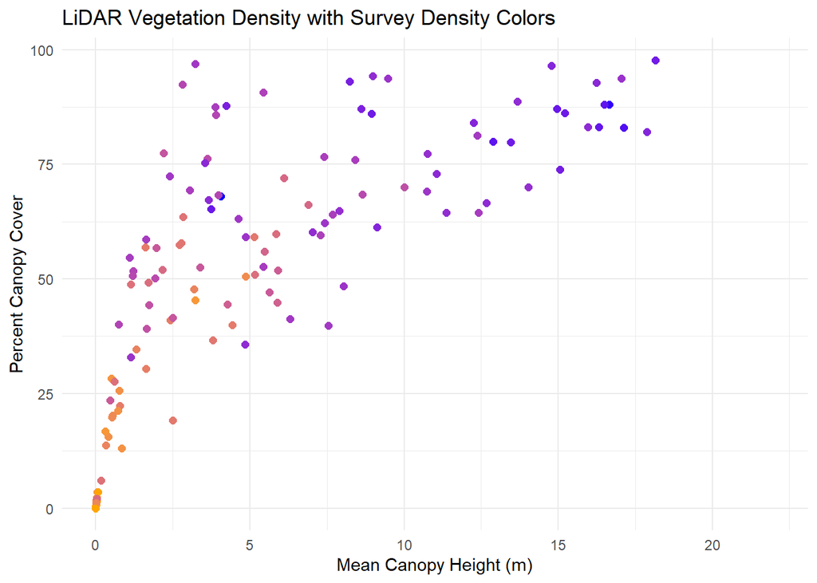

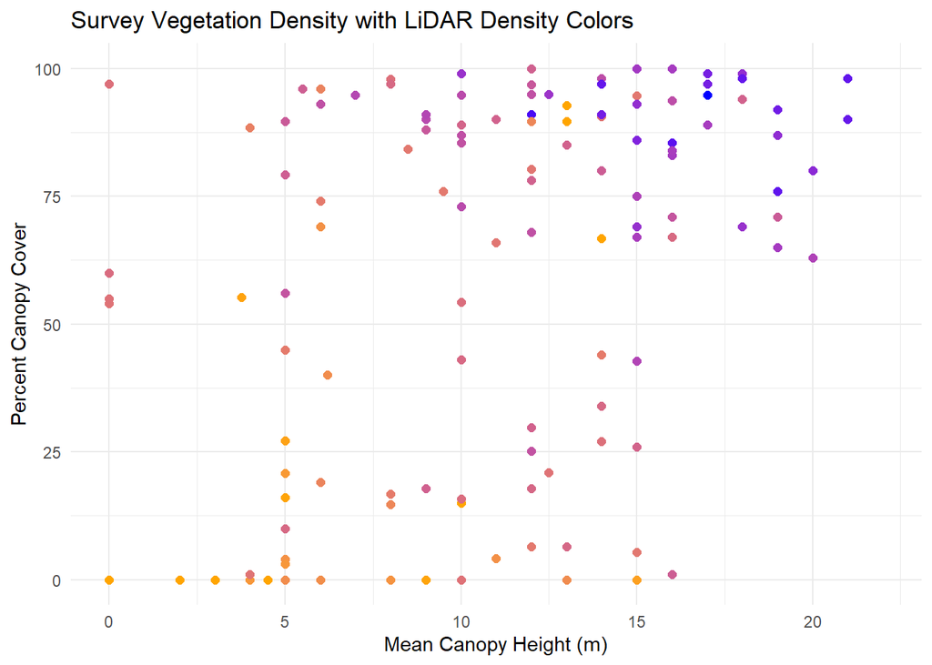

## Plot difference between measures from each method spatially

Let’s take a look at how the differences between the measurements look when plotting to the coordinates of each point.

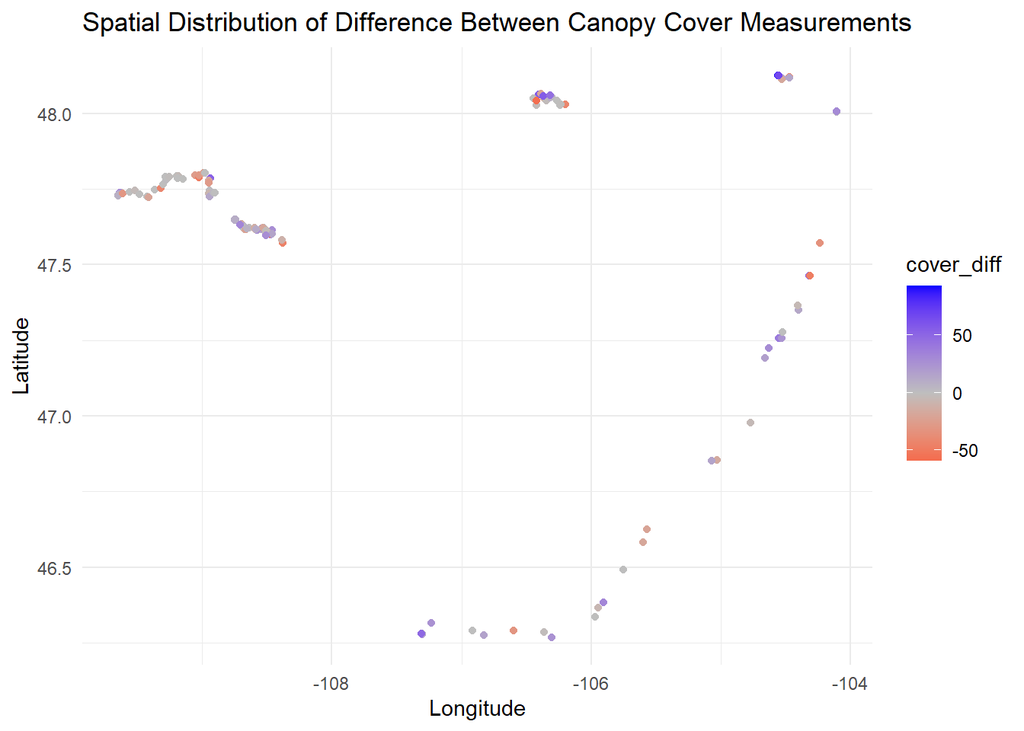

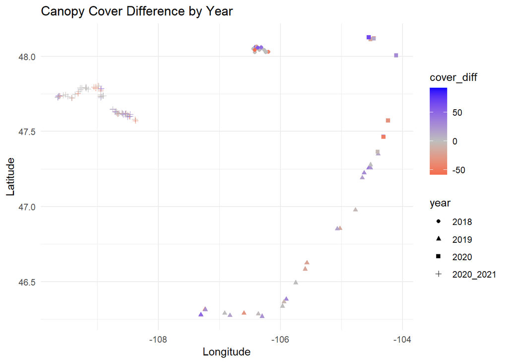

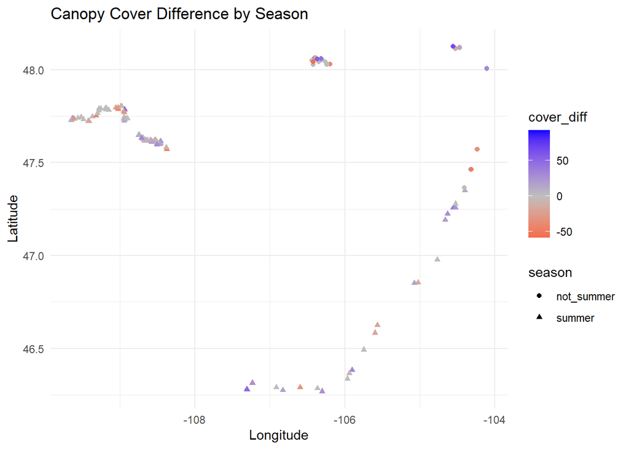

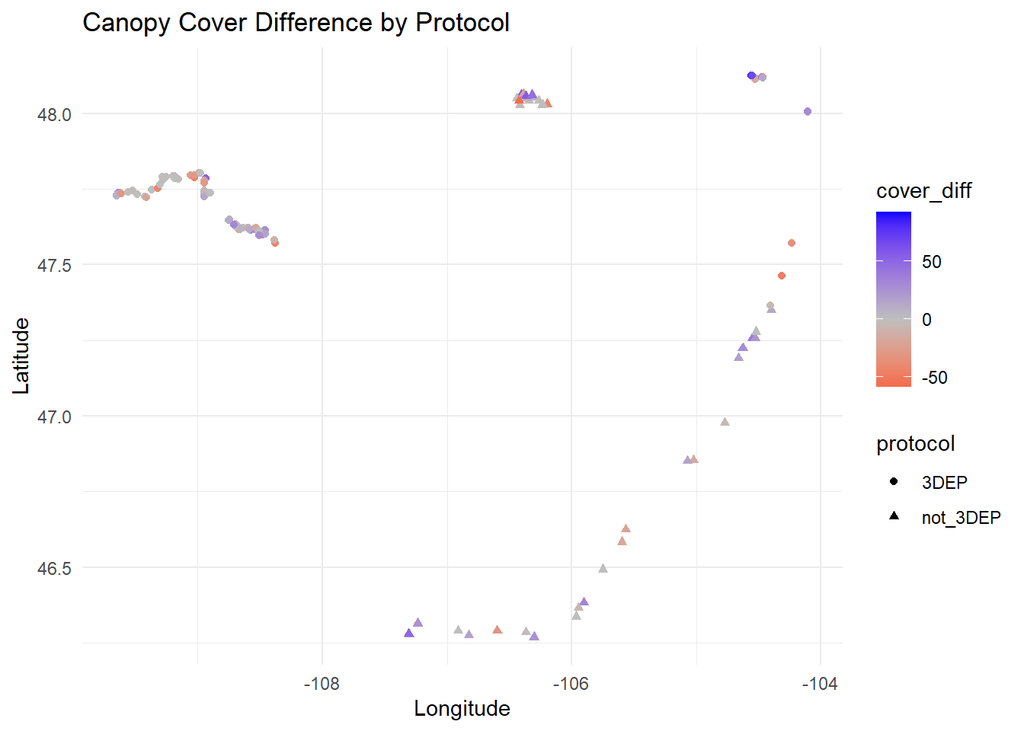

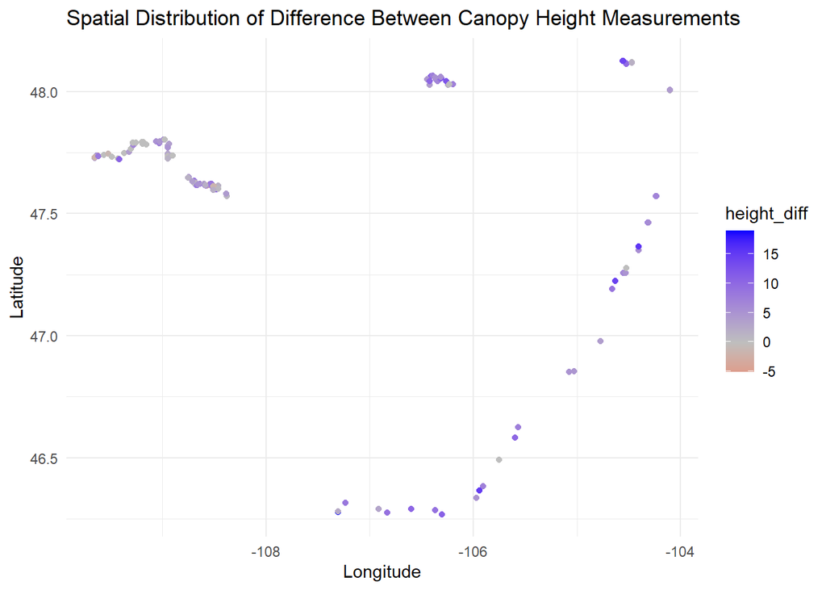

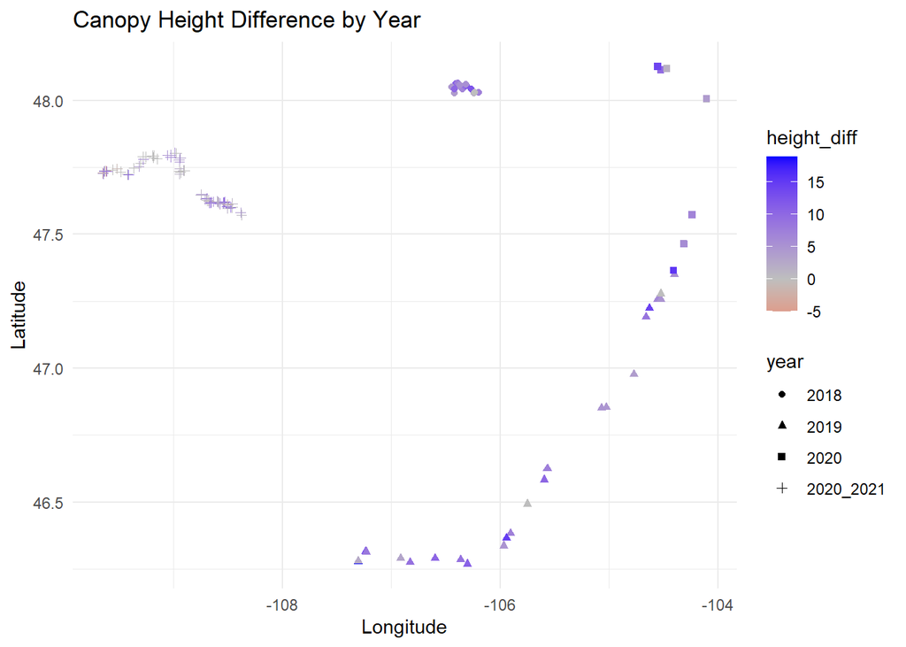

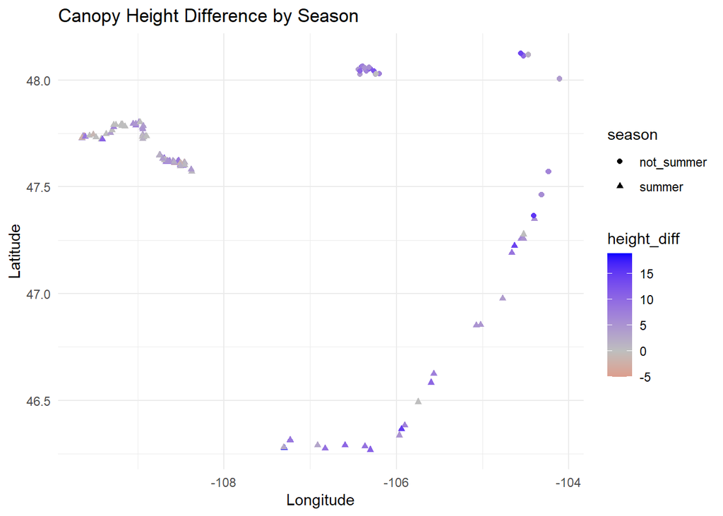

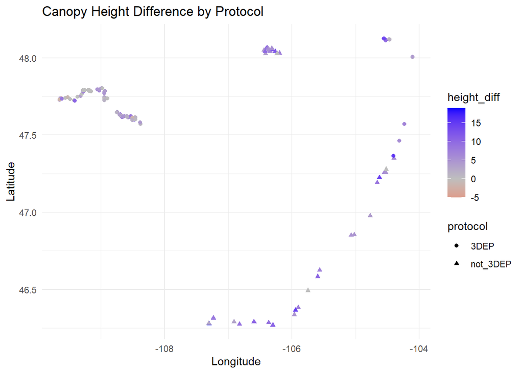